# Fertility Data

Sanjay

2023-07-08

#Leading a long and healthy life is a priority as humans. Especially in this day and age, we need to keep track of the countless factors that could be having impacts on our well being and longevity. This data set presents numerous factors that one could experience in a lifetime that may have extreme effects on ones health. Thus, I wanted to how much each of these variables play a role in ones health, and see if I can use them optimize a long and safe life.

#This dataset includes 10 variables: Season, Age, Childish diseases, accident or serious trauma, surgical intervention, high fevers in the last year, frequency of alcohol consumption, smoking habits, hours spent sitting per day, and the condition of each respondents semen. Childish diseases signifies whether or not the individual had a disease as a child, accident or serious trauma corresponds to whether or not the individual has suffered a recent accident or had serious trauma. All of these variables are general indicators of health for men in this case.

#Using the data, I want to see which variables have impacts on other variables. I am curious to see which factors have the most impact on semen condition. I also want to investigate which factors influence ones lifestyle habits. Lastly, I want to investigate the ways to predict whether an individual will experience trauma, and the effects of this trauma.

```r
library(tidyverse)
library(modelr)
library(broom)
library(purrr)
library(Metrics)
```

```r
library(dplyr)
library(ggplot2)
library(Hmisc)
library(corrplot)
library(plotly)
library(reshape2)
library(leaps)
library(margins)
library(yardstick)
library(randomForest)
library(caret)
library(MASS)
library(car)
library(naivebayes)
library(bestglm)
library(pROC)
fert = read_csv('fertility.csv')
head(fert, 10)
```

```
## # A tibble: 10 x 10
##    Season   Age `Childish diseases` `Accident or serious trauma`
##    <chr>  <dbl> <chr>               <chr>
##  1 spring    30 no                  yes
##  2 spring    35 yes                 no
##  3 spring    27 yes                 no
##  4 spring    32 no                  yes
##  5 spring    30 yes                 yes
##  6 spring    30 yes                 no
##  7 spring    30 no                  no
##  8 spring    36 yes                 yes
##  9 fall      30 no                  no
## 10 fall      29 yes                 no
## # i 6 more variables: `Surgical intervention` <chr>,
## #   `High fevers in the last year` <chr>,
## #   `Frequency of alcohol consumption` <chr>, `Smoking habit` <chr>,
## #   `Number of hours spent sitting per day` <dbl>, Diagnosis <chr>
```

#data cleaning

```r
dim(fert)
```

```
## [1] 100  10
```

```r
columns = c(colnames(fert))
columns
```

```
##  [1] "Season"
##  [2] "Age"
##  [3] "Childish diseases"
##  [4] "Accident or serious trauma"
##  [5] "Surgical intervention"
##  [6] "High fevers in the last year"
##  [7] "Frequency of alcohol consumption"
##  [8] "Smoking habit"
##  [9] "Number of hours spent sitting per day"
## [10] "Diagnosis"
```

```r
#Find unique values for each variable.
for (i in columns) {
 uniquevals = unique(fert[i])
 print(uniquevals)
}
```

```
## # A tibble: 4 x 1
##   Season
##   <chr>
## 1 spring
## 2 fall
## 3 winter
## 4 summer
## # A tibble: 10 x 1
##      Age
##    <dbl>
##  1    30
##  2    35
##  3    27
##  4    32
##  5    36
##  6    29
##  7    33
##  8    28
##  9    31
## 10    34
## # A tibble: 2 x 1
##   `Childish diseases`
##   <chr>
## 1 no
## 2 yes
## # A tibble: 2 x 1
##   `Accident or serious trauma`
##   <chr>
## 1 yes
## 2 no
## # A tibble: 2 x 1
##   `Surgical intervention`
##   <chr>
## 1 yes
## 2 no
## # A tibble: 3 x 1
##   `High fevers in the last year`
##   <chr>
## 1 more than 3 months ago
## 2 less than 3 months ago
```

[output cut: 22 more lines]

```
##  5                                       8
##  6                                       5
##  7                                       2
##  8                                      11
##  9                                       3
## 10                                     342
## 11                                      14
## 12                                      18
## 13                                      10
## 14                                       1
## # A tibble: 2 x 1
##   Diagnosis
##   <chr>
## 1 Normal
## 2 Altered
```

```r
#rename columns
fert1 = fert %>%
  rename('child_disease'= 'Childish diseases' , 'trauma' = 'Accident or serious trauma' , 'surgery' = 'Surgical intervention',  'fever' = 'High fevers in the last year' ,  'alcohol_consumption' = 'Frequency of alcohol consumption' ,  'smoking_frequency' = 'Smoking habit' , 'hours_sitting_daily' = 'Number of hours spent sitting per day' )
fert1
```

```
## # A tibble: 100 x 10
##    Season   Age child_disease trauma surgery fever           alcohol_consumption
##    <chr>  <dbl> <chr>         <chr>  <chr>   <chr>           <chr>
##  1 spring    30 no            yes    yes     more than 3 mo~ once a week
##  2 spring    35 yes           no     yes     more than 3 mo~ once a week
##  3 spring    27 yes           no     no      more than 3 mo~ hardly ever or nev~
##  4 spring    32 no            yes    yes     more than 3 mo~ hardly ever or nev~
##  5 spring    30 yes           yes    no      more than 3 mo~ once a week
##  6 spring    30 yes           no     yes     more than 3 mo~ once a week
##  7 spring    30 no            no     no      less than 3 mo~ once a week
##  8 spring    36 yes           yes    yes     more than 3 mo~ several times a we~
##  9 fall      30 no            no     yes     more than 3 mo~ once a week
## 10 fall      29 yes           no     no      more than 3 mo~ hardly ever or nev~
## # i 90 more rows
## # i 3 more variables: smoking_frequency <chr>, hours_sitting_daily <dbl>,
## #   Diagnosis <chr>
```

```r
#convert categorical data into factors
fert1$Season = as.factor(fert1$Season)
fert1$fever = as.factor(fert1$fever)
fert1$alcohol_consumption = as.factor(fert1$alcohol_consumption)
fert1$smoking_frequency = as.factor(fert1$smoking_frequency)

str(fert1)
```

```
## spc_tbl_ [100 x 10] (S3: spec_tbl_df/tbl_df/tbl/data.frame)
##  $ Season             : Factor w/ 4 levels "fall","spring",..: 2 2 2 2 2 2 2 2 1 1 ...
##  $ Age                : num [1:100] 30 35 27 32 30 30 30 36 30 29 ...
##  $ child_disease      : chr [1:100] "no" "yes" "yes" "no" ...
##  $ trauma             : chr [1:100] "yes" "no" "no" "yes" ...
##  $ surgery            : chr [1:100] "yes" "yes" "no" "yes" ...
##  $ fever              : Factor w/ 3 levels "less than 3 months ago",..: 2 2 2 2 2 2 1 2 2 2 ...
##  $ alcohol_consumption: Factor w/ 5 levels "every day","hardly ever or never",..: 3 3 2 2 3 3 3 5 3 2 ...
##  $ smoking_frequency  : Factor w/ 3 levels "daily","never",..: 3 1 2 2 2 3 2 2 2 2 ...
##  $ hours_sitting_daily: num [1:100] 16 6 9 7 9 9 8 7 5 5 ...
##  $ Diagnosis          : chr [1:100] "Normal" "Altered" "Normal" "Normal" ...
##  - attr(*, "spec")=
##   .. cols(
##   ..   Season = col_character(),
##   ..   Age = col_double(),
##   ..   `Childish diseases` = col_character(),
##   ..   `Accident or serious trauma` = col_character(),
##   ..   `Surgical intervention` = col_character(),
##   ..   `High fevers in the last year` = col_character(),
##   ..   `Frequency of alcohol consumption` = col_character(),
##   ..   `Smoking habit` = col_character(),
##   ..   `Number of hours spent sitting per day` = col_double(),
##   ..   Diagnosis = col_character()
##   .. )
##  - attr(*, "problems")=<externalptr>
```

```r
#convert binary data into numeric
for (i in 1:100) {
  if (fert1$child_disease[i] == 'no') {
    fert1$child_disease[i] = '0'

  } else {
    fert1$child_disease[i] = '1'
  }
}

for (i in 1:100) {
  if (fert1$trauma[i] == 'no') {
    fert1$trauma[i] = '0'

  } else {
    fert1$trauma[i] = '1'
  }
}

for (i in 1:100) {
  if (fert1$surgery[i] == 'no') {
    fert1$surgery[i] = '0'

  } else {
    fert1$surgery[i] = '1'
  }

}

for (i in 1:100) {
  if (fert1$Diagnosis[i] == 'Normal') {
    fert1$Diagnosis[i] = '0'

  } else {
    fert1$Diagnosis[i] = '1'
  }
}

fert1$child_disease = as.numeric(fert1$child_disease)
fert1$trauma = as.numeric(fert1$trauma)
fert1$surgery = as.numeric(fert1$surgery)
fert1$Diagnosis = as.numeric(fert1$Diagnosis)

#All binary response variables were recoded as 1 being yes, and 0 being no. Diagnosis was recoded as 0 being normal semen and 1 being altered semen.

fert1
```

```
## # A tibble: 100 x 10
##    Season   Age child_disease trauma surgery fever           alcohol_consumption
##    <fct>  <dbl>         <dbl>  <dbl>   <dbl> <fct>           <fct>
##  1 spring    30             0      1       1 more than 3 mo~ once a week
##  2 spring    35             1      0       1 more than 3 mo~ once a week
##  3 spring    27             1      0       0 more than 3 mo~ hardly ever or nev~
##  4 spring    32             0      1       1 more than 3 mo~ hardly ever or nev~
##  5 spring    30             1      1       0 more than 3 mo~ once a week
##  6 spring    30             1      0       1 more than 3 mo~ once a week
##  7 spring    30             0      0       0 less than 3 mo~ once a week
##  8 spring    36             1      1       1 more than 3 mo~ several times a we~
##  9 fall      30             0      0       1 more than 3 mo~ once a week
## 10 fall      29             1      0       0 more than 3 mo~ hardly ever or nev~
## # i 90 more rows
## # i 3 more variables: smoking_frequency <fct>, hours_sitting_daily <dbl>,
## #   Diagnosis <dbl>
```

#Visualizing distributions of quantitative variables.

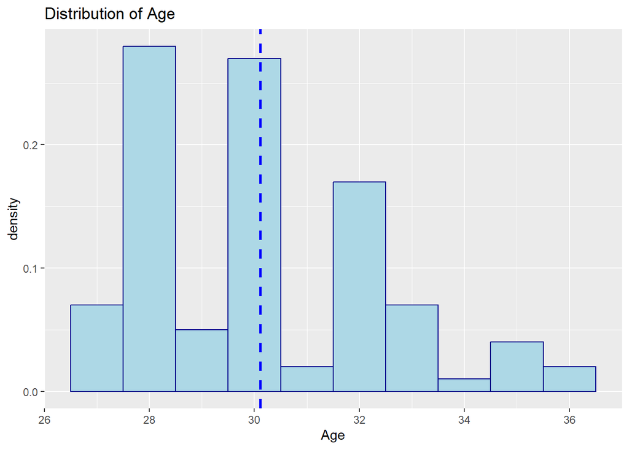

```r
ggplot(fert1, aes(x=Age)) + geom_histogram(aes(y=..density..), colour="darkblue", fill="lightblue" , binwidth = 1) + geom_vline(aes(xintercept=mean(Age)),color="blue", linetype="dashed", size=1) + ggtitle("Distribution of Age")
```

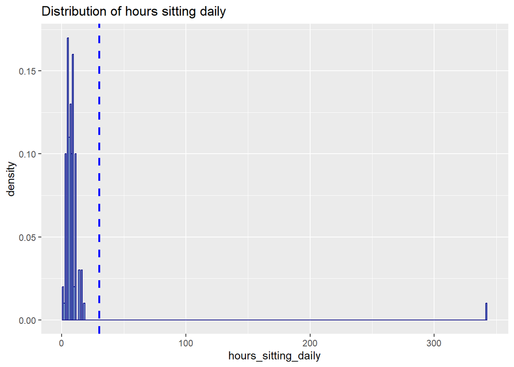

```r
ggplot(fert1, aes(x=hours_sitting_daily)) + geom_histogram(aes(y=..density..), colour="darkblue", fill="lightblue" , binwidth = 1) + geom_vline(aes(xintercept=mean(Age)),color="blue", linetype="dashed", size=1) + ggtitle("Distribution of hours sitting daily")
```

```r
#Based on this histogram there seems to be a massive outlier.
```

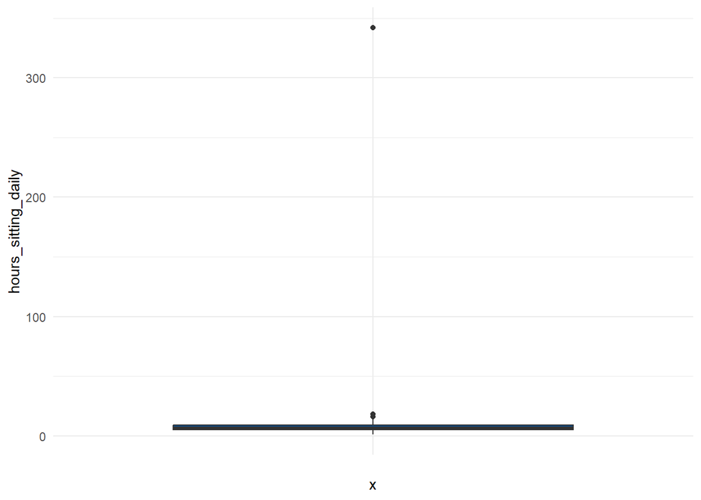

```r
#Checking outlier with a boxplot
ggplot(fert1) +
  aes(x = "", y = hours_sitting_daily) +
  geom_boxplot(fill = "#0c4c8a") +
  theme_minimal()
```

```r
#Based on the boxplot this point is a massive outlier, as it lies far outside the interquartile range.
```

```r
fert1 %>% filter(hours_sitting_daily >300)
```

```
## # A tibble: 1 x 10
##   Season   Age child_disease trauma surgery fever            alcohol_consumption
##   <fct>  <dbl>         <dbl>  <dbl>   <dbl> <fct>            <fct>
## 1 spring    30             1      0       1 more than 3 mon~ once a week
## # i 3 more variables: smoking_frequency <fct>, hours_sitting_daily <dbl>,
## #   Diagnosis <dbl>
```

```r
#Identifying the outlier.
```

```r
#Dropping the outlier.
fert2 = subset(fert1,hours_sitting_daily < 300 )
fert2
```

```
## # A tibble: 99 x 10
##    Season   Age child_disease trauma surgery fever           alcohol_consumption
##    <fct>  <dbl>         <dbl>  <dbl>   <dbl> <fct>           <fct>
##  1 spring    30             0      1       1 more than 3 mo~ once a week
##  2 spring    35             1      0       1 more than 3 mo~ once a week
##  3 spring    27             1      0       0 more than 3 mo~ hardly ever or nev~
##  4 spring    32             0      1       1 more than 3 mo~ hardly ever or nev~
##  5 spring    30             1      1       0 more than 3 mo~ once a week
##  6 spring    30             1      0       1 more than 3 mo~ once a week
##  7 spring    30             0      0       0 less than 3 mo~ once a week
##  8 spring    36             1      1       1 more than 3 mo~ several times a we~
##  9 fall      30             0      0       1 more than 3 mo~ once a week
## 10 fall      29             1      0       0 more than 3 mo~ hardly ever or nev~
## # i 89 more rows
## # i 3 more variables: smoking_frequency <fct>, hours_sitting_daily <dbl>,
## #   Diagnosis <dbl>
```

```r
for (i in 1:length(fert2$hours_sitting_daily)) {
  fert2$hours_sitting_daily[i] = (fert2$hours_sitting_daily[i])/24

}

fert3 = fert2 %>% rename("prop_day_sitting" = 'hours_sitting_daily')

fert3
```

```
## # A tibble: 99 x 10
##    Season   Age child_disease trauma surgery fever           alcohol_consumption
##    <fct>  <dbl>         <dbl>  <dbl>   <dbl> <fct>           <fct>
##  1 spring    30             0      1       1 more than 3 mo~ once a week
##  2 spring    35             1      0       1 more than 3 mo~ once a week
##  3 spring    27             1      0       0 more than 3 mo~ hardly ever or nev~
##  4 spring    32             0      1       1 more than 3 mo~ hardly ever or nev~
##  5 spring    30             1      1       0 more than 3 mo~ once a week
##  6 spring    30             1      0       1 more than 3 mo~ once a week
##  7 spring    30             0      0       0 less than 3 mo~ once a week
##  8 spring    36             1      1       1 more than 3 mo~ several times a we~
##  9 fall      30             0      0       1 more than 3 mo~ once a week
## 10 fall      29             1      0       0 more than 3 mo~ hardly ever or nev~
## # i 89 more rows
## # i 3 more variables: smoking_frequency <fct>, prop_day_sitting <dbl>,
## #   Diagnosis <dbl>
```

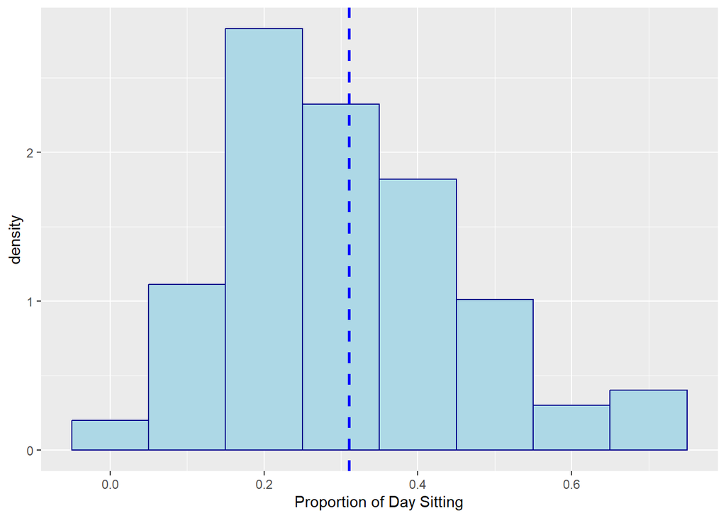

```r
#Recoding hour_sitting_daily to proportion of day sitting to make it easier to work with.

ggplot(fert3, aes(x=prop_day_sitting)) + geom_histogram(aes(y=..density..), colour="darkblue", fill="lightblue" , binwidth = .1) + geom_vline(aes(xintercept=mean(prop_day_sitting)),color="blue", linetype="dashed", size=1) + xlab("Proportion of Day Sitting")
```

```r
summary(fert3)
```

```
##     Season        Age        child_disease        trauma          surgery
##  fall  :31   Min.   :27.00   Min.   :0.0000   Min.   :0.0000   Min.   :0.0000
##  spring:36   1st Qu.:28.00   1st Qu.:1.0000   1st Qu.:0.0000   1st Qu.:0.0000
##  summer: 4   Median :30.00   Median :1.0000   Median :0.0000   Median :1.0000
##  winter:28   Mean   :30.11   Mean   :0.8687   Mean   :0.4444   Mean   :0.5051
##              3rd Qu.:32.00   3rd Qu.:1.0000   3rd Qu.:1.0000   3rd Qu.:1.0000
##              Max.   :36.00   Max.   :1.0000   Max.   :1.0000   Max.   :1.0000
##                     fever              alcohol_consumption  smoking_frequency
##  less than 3 months ago: 9   every day           : 1       daily     :21
##  more than 3 months ago:62   hardly ever or never:40       never     :55
##  no                    :28   once a week         :38       occasional:23
##                              several times a day : 1
##                              several times a week:19
##
##  prop_day_sitting    Diagnosis
##  Min.   :0.04167   Min.   :0.0000
##  1st Qu.:0.20833   1st Qu.:0.0000
##  Median :0.29167   Median :0.0000
##  Mean   :0.31061   Mean   :0.1212
##  3rd Qu.:0.37500   3rd Qu.:0.0000
##  Max.   :0.75000   Max.   :1.0000
```

```r
#since there is only 1 response for alcohol consumption several times a day and every day, I am going to combine them with several times a week into a new response reading several times a week or more.
```

```r
fert4 = fert3 %>%
 mutate(alcohol_consumption = fct_collapse(alcohol_consumption,
 'several times a week or more' = c("several times a day", "every day", 'several times a week')))
```

```r
lifestyle.score = function(smoking,alcohol,sitting,fever){
  score = c(rep(0,99))
  i = 1

  while (i <= 99) {
    if (smoking[i] == 'daily') {
      score[i] = score[i] + 1
    } else if (smoking[i] == 'occasional') {
      score[i] = score[i] + 2
    } else if (smoking[i] == 'never') {
      score[i] = score[i] + 3}

     if (alcohol[i] == 'daily') {
      score[i] = score[i] + 1
    } else if (alcohol[i] == 'once a week') {
      score[i] = score[i] + 2
    } else if (alcohol[i] == 'hardly ever or never') {
      score[i] = score[i] + 3}

     if (sitting[i] < 0.25) {
      score[i] = score[i] + 3
    } else if (between(sitting[i], .25,.50)) {
      score[i] = score[i] + 2
    } else if (sitting[i] > 0.50) {
      score[i] = score[i] + 1}

     if (fever[i] == 'less than 3 months ago') {
      score[i] = score[i] + 0
    } else {
      score[i] = score[i] + 1}
    i = i + 1
    }
  return (score)
}


fert4$lifestyle = lifestyle.score(fert4$smoking_frequency, fert4$alcohol_consumption, fert4$prop_day_sitting, fert4$fever)


summary(fert4$lifestyle)
```

```
##    Min. 1st Qu.  Median    Mean 3rd Qu.    Max.
##   4.000   6.000   8.000   7.465   9.000  10.000
```

#Lifestyle score was created using the variables: frequency of alcohol consumption, smoking frequency, recent fever, and proportion of day sitting. A higher lifestyle score is better and vice versa. This might be an interesting variable to predict, to identify risk factors or the effects of a poor lifestyle.

```r
summary(fert4)
```

```
##     Season        Age        child_disease        trauma          surgery
##  fall  :31   Min.   :27.00   Min.   :0.0000   Min.   :0.0000   Min.   :0.0000
##  spring:36   1st Qu.:28.00   1st Qu.:1.0000   1st Qu.:0.0000   1st Qu.:0.0000
##  summer: 4   Median :30.00   Median :1.0000   Median :0.0000   Median :1.0000
##  winter:28   Mean   :30.11   Mean   :0.8687   Mean   :0.4444   Mean   :0.5051
##              3rd Qu.:32.00   3rd Qu.:1.0000   3rd Qu.:1.0000   3rd Qu.:1.0000
##              Max.   :36.00   Max.   :1.0000   Max.   :1.0000   Max.   :1.0000
##                     fever                      alcohol_consumption
##  less than 3 months ago: 9   several times a week or more:21
##  more than 3 months ago:62   hardly ever or never        :40
##  no                    :28   once a week                 :38
##
##
##
##   smoking_frequency prop_day_sitting    Diagnosis        lifestyle
##  daily     :21      Min.   :0.04167   Min.   :0.0000   Min.   : 4.000
##  never     :55      1st Qu.:0.20833   1st Qu.:0.0000   1st Qu.: 6.000
##  occasional:23      Median :0.29167   Median :0.0000   Median : 8.000
##                     Mean   :0.31061   Mean   :0.1212   Mean   : 7.465
##                     3rd Qu.:0.37500   3rd Qu.:0.0000   3rd Qu.: 9.000
##                     Max.   :0.75000   Max.   :1.0000   Max.   :10.000
```

#Visualizing relationships between variables

```r
#correlations between numeric variables including diagnosis.
fert_num = fert4 %>% select_if(is.numeric)
correlations = round(cor(fert_num),2)
correlations
```

```
##                    Age child_disease trauma surgery prop_day_sitting Diagnosis
## Age               1.00          0.10   0.24    0.26            -0.42      0.09
## child_disease     0.10          1.00   0.17   -0.15            -0.14     -0.04
## trauma            0.24          0.17   1.00    0.11             0.01     -0.15
## surgery           0.26         -0.15   0.11    1.00            -0.19      0.06
## prop_day_sitting -0.42         -0.14   0.01   -0.19             1.00      0.02
## Diagnosis         0.09         -0.04  -0.15    0.06             0.02      1.00
## lifestyle        -0.06          0.00  -0.24    0.06            -0.20     -0.19
##                  lifestyle
## Age                  -0.06
## child_disease         0.00
## trauma               -0.24
## surgery               0.06
## prop_day_sitting     -0.20
## Diagnosis            -0.19
## lifestyle             1.00
```

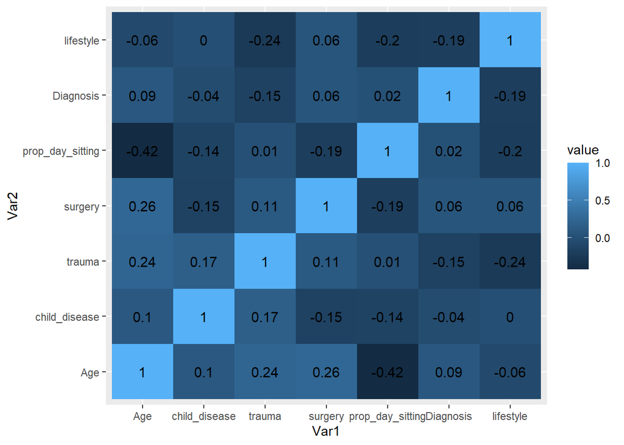

```r
melted_corr_mat <- melt(correlations)
# head(melted_corr_mat)

# plotting the correlation heatmap
library(ggplot2)
ggplot(data = melted_corr_mat, aes(x=Var1, y=Var2,
                                   fill=value)) +
geom_tile() + geom_text(aes(Var2, Var1, label = value),
          color = "black", size = 4)
```

```r
# No variables seem to have a very strong linear correlation based on the heat map apart from proportion of day sitting and age. This is interesting because it goes against what one would expect, being older results in less time sitting per day. However, due to the small age range, this might be coincidental.
```

#Diagnosis is not very strongly correlated with many other variables, which I will further investigate through plots. Proportion of day sitting and age have the strongest correlation with each other out of the data. Trauma and lifestyle, as well as Diagnosis and lifestyle also have a mdoerate correlation compared to the other variables. This might be worth investigating further.

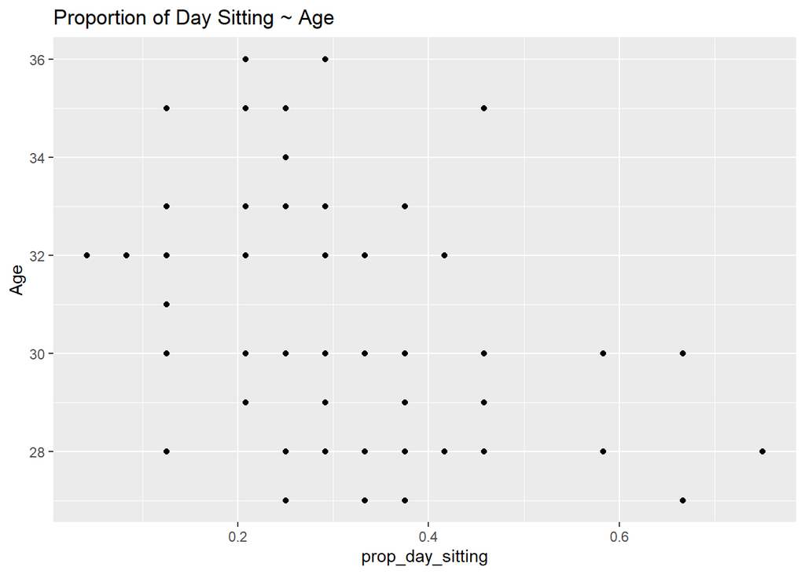

```r
#Visualizing Proportion of day sitting versus age.
ggplot(fert4) + geom_point(aes(x = prop_day_sitting, y = Age)) + ggtitle("Proportion of Day Sitting ~ Age")
```

#However, apart from the higher values for proportion of day sitting, the distribution of proportion of day sitting with age seems to be very random. It does not seem to be correlated in any predictable way, so I will not be looking into this relationship further.

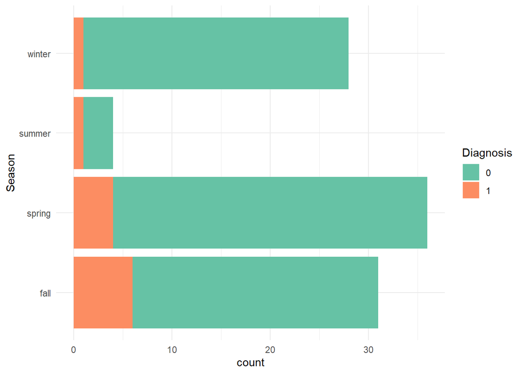

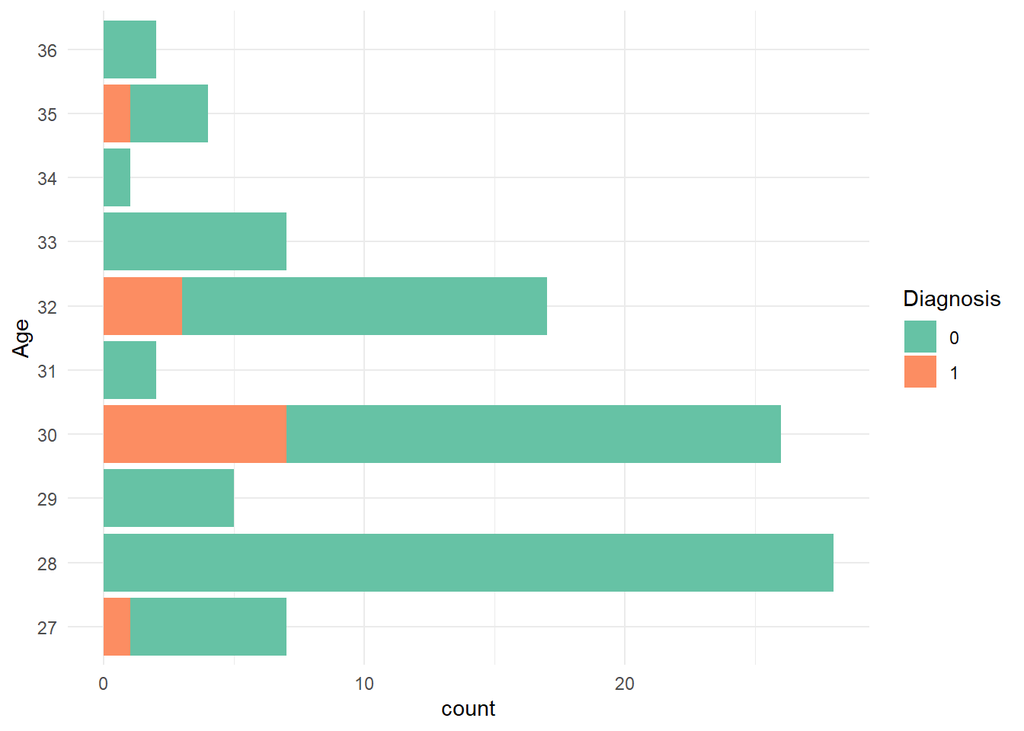

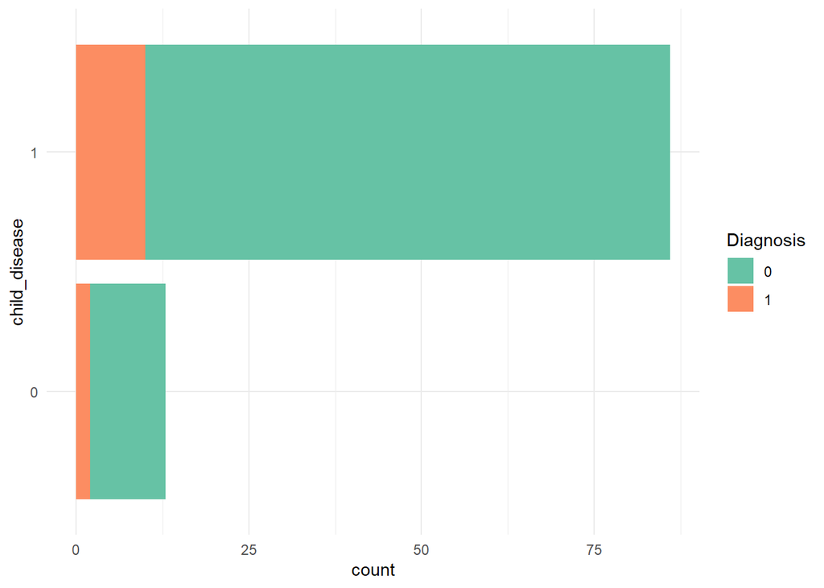

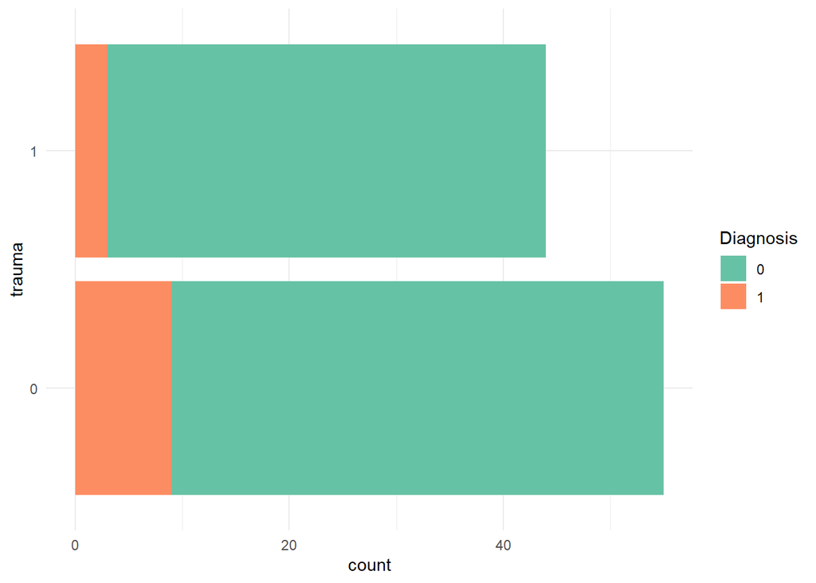

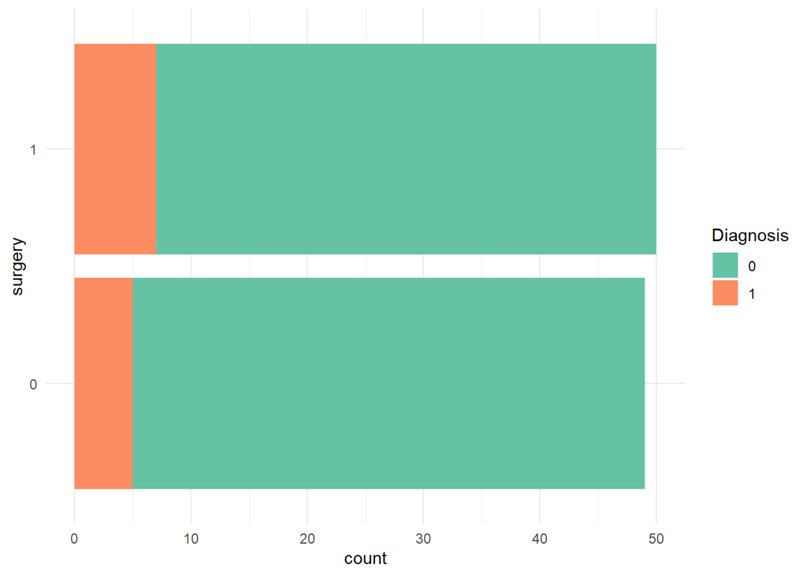

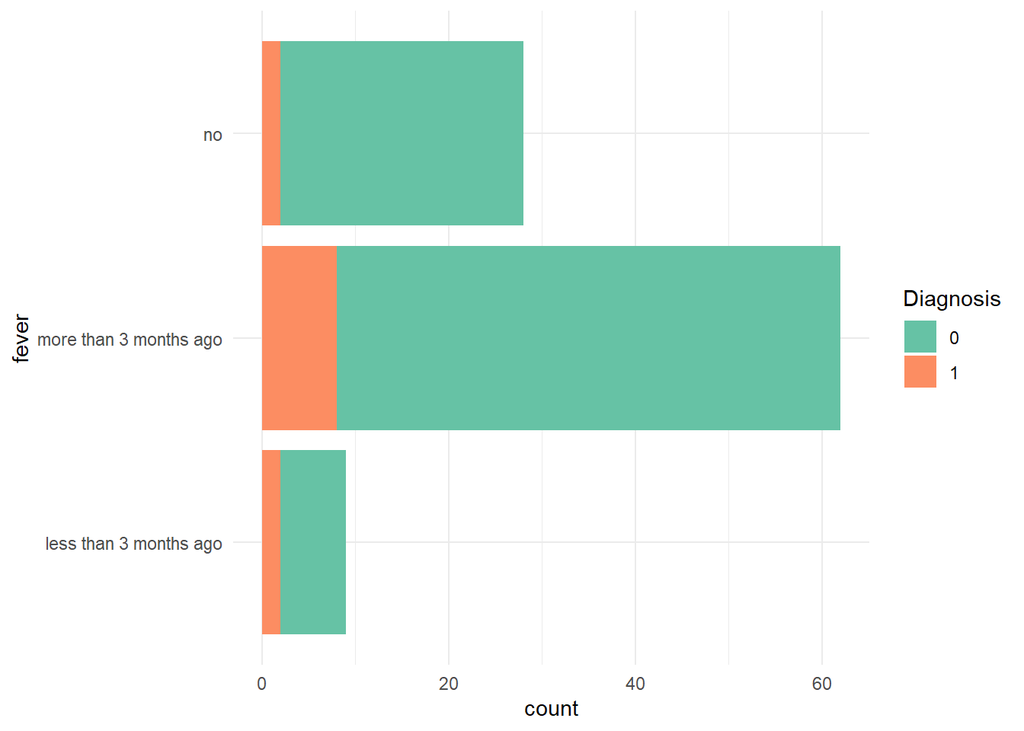

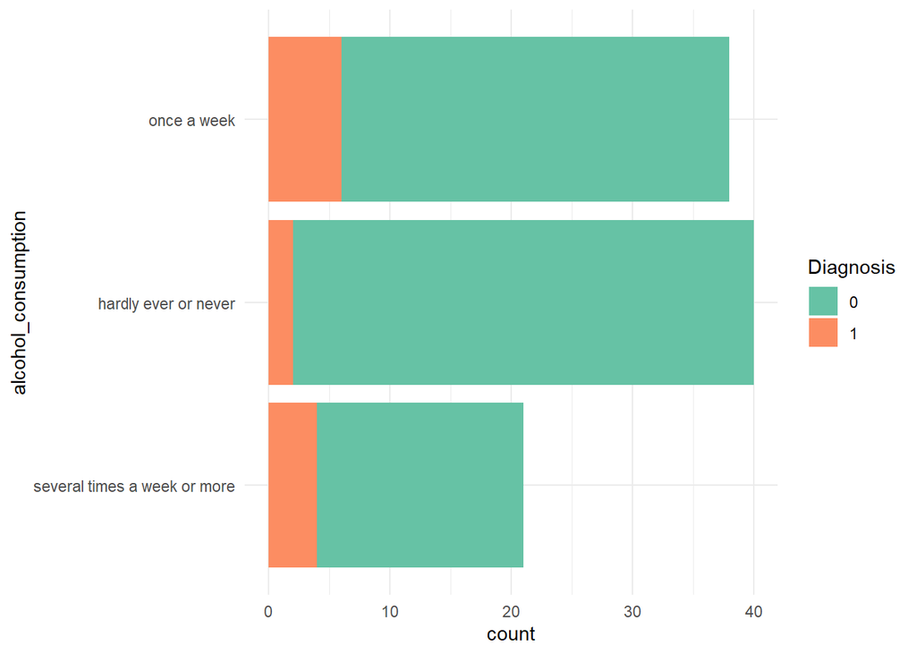

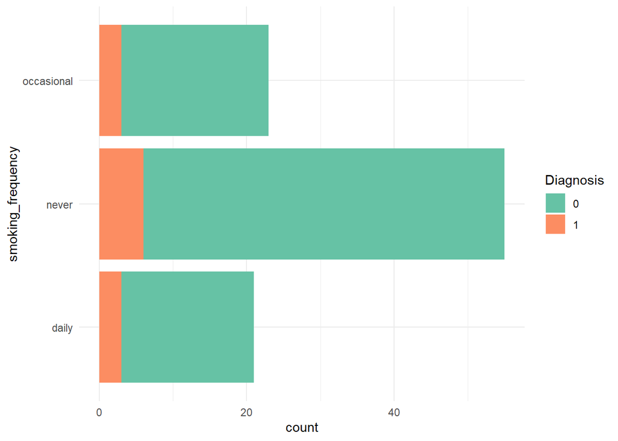

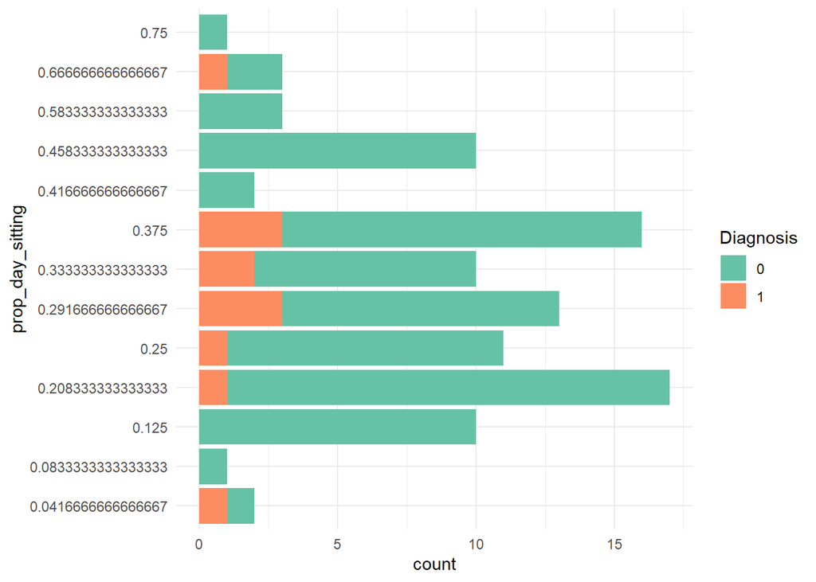

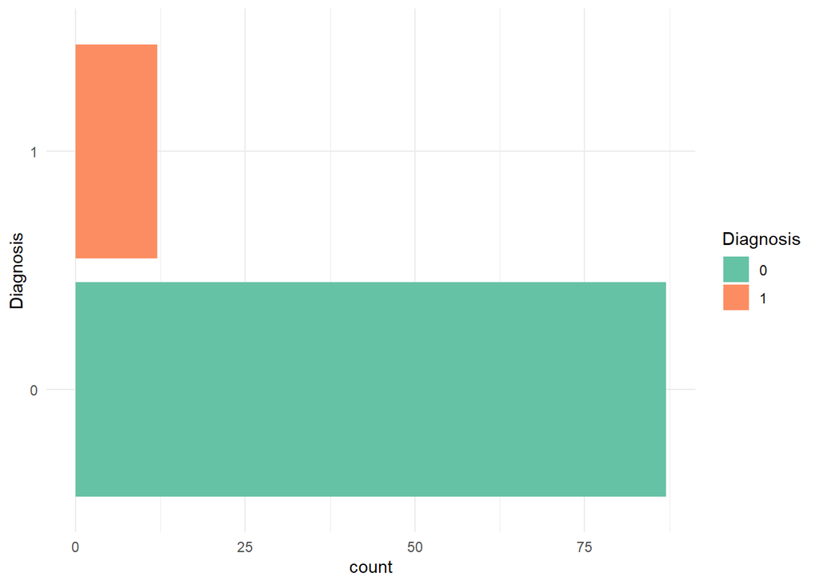

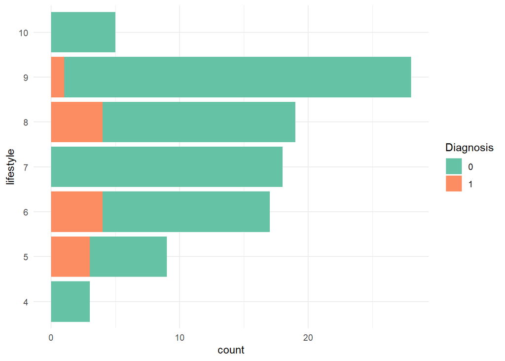

```r
#Relationships between all variables and diagnosis.
fert4cols = c(colnames(fert4))
for (i in fert4cols){
  plt = ggplot(fert4,
         aes(x = factor(.data[[i]]),
             fill = factor(Diagnosis)))+
    geom_bar(position = "stack") +
    scale_fill_brewer(palette = "Set2") +
    labs(y = "count",
         fill = "Diagnosis",
         x = i)+
    theme_minimal() + coord_flip()
  print(plt)
}
```

#Based on these plots, it seems as though most variables have very little correlation to diagnosis. However, some variables, such as age, season, lifestyle, trauma, and childish diseases may have a slight relationship with diagnosis.

#From the previous correlation plot, many variables seemed to have a relationship with trauma and lifestyle. I will further investigate these variables.

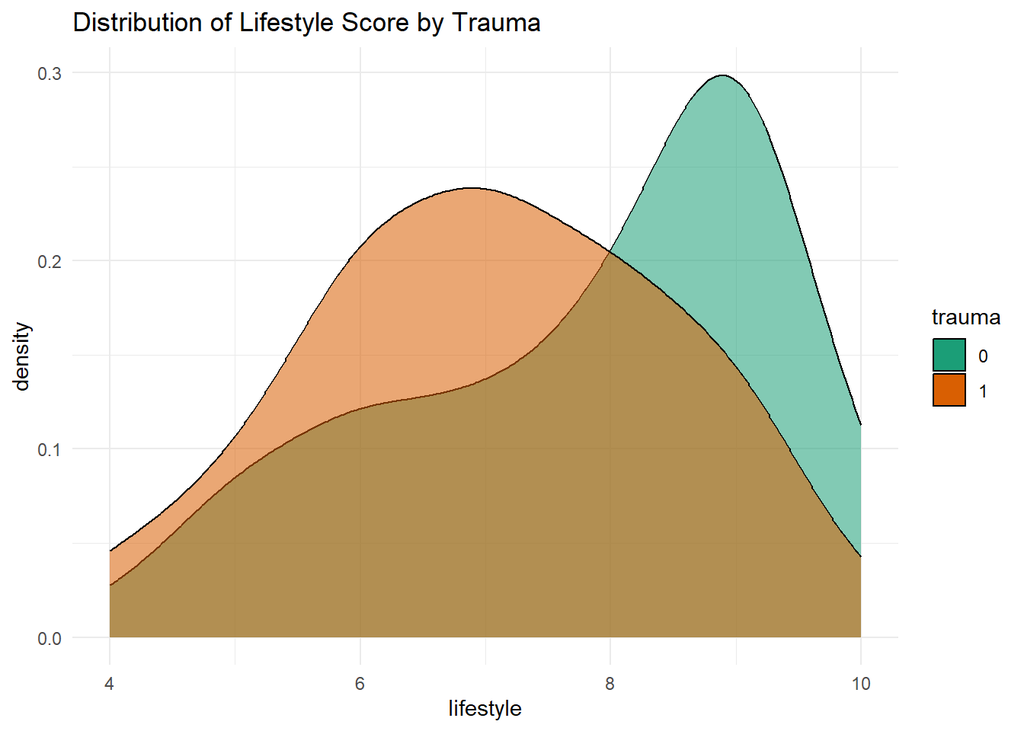

```r
ggplot(fert4) + geom_density(aes(x=lifestyle, fill=factor(trauma), alpha = 0.4))  + scale_fill_brewer(palette="Dark2") + theme_minimal() + ggtitle("Distribution of Lifestyle Score by Trauma") + labs(fill = "trauma") + guides(alpha = F)
```

#Individuals without serious trauma tend to have better lifestyle scores. This begs the question: does having previous accidents and trauma cause ones lifestyle to become worse? Or does ones lifestyle being worse cause people to experience trauma? Either way this relationship could be useful.

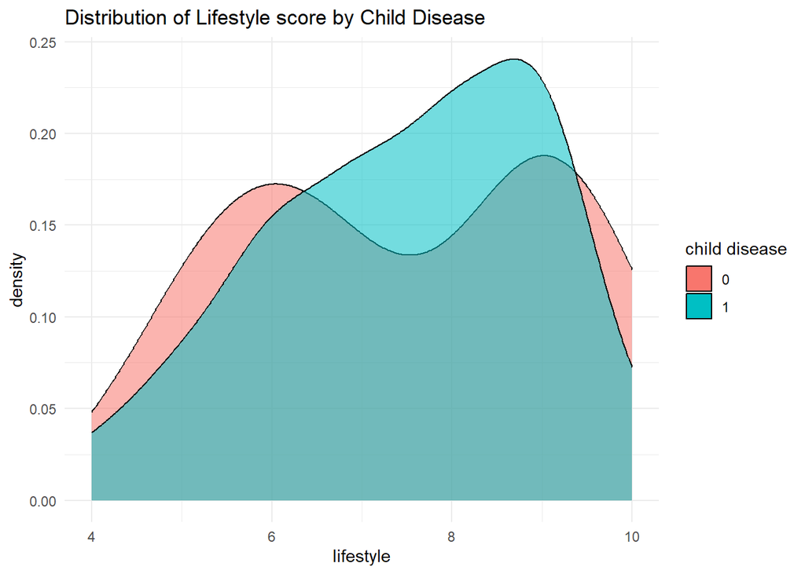

```r
ggplot(fert4) + geom_density(aes(x=lifestyle, fill=factor(child_disease), alpha = .3))  + scale_color_brewer(palette="Dark2") + theme_minimal() + ggtitle("Distribution of Lifestyle score by Child Disease") + labs(fill = "child disease") + guides(alpha = F)
```

#There are more indivduals who had a disease as a child that have better lifestyle scores. This makes sense, as those who had conditions as a child might be more inclined to lead healthier lifestyles later in life.

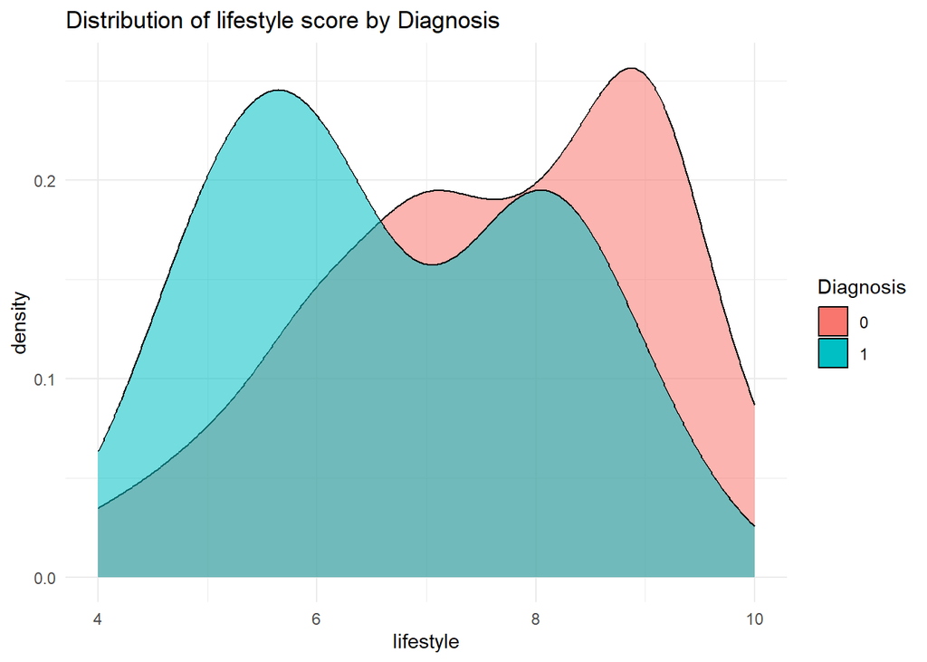

```r
ggplot(fert4) + geom_density(aes(x=lifestyle, fill=factor(Diagnosis), alpha = 0.3)) + scale_color_brewer(palette="Dark2") + theme_minimal() + ggtitle("Distribution of lifestyle score by Diagnosis") + labs(fill = "Diagnosis") + guides(alpha  =F)
```

#There are significantly more individuals who have lower lifestyle scores that also have altered semen.

#Based on these plots, I want to use the dataset to create a model that can predict lifestyle score.

```r
fullmod = lm(lifestyle ~ Season + Age + child_disease + Diagnosis + surgery + trauma , data = fert4 )
summary(fullmod)
```

```
##
## Call:
## lm(formula = lifestyle ~ Season + Age + child_disease + Diagnosis +
##     surgery + trauma, data = fert4)
##
## Residuals:
##     Min      1Q  Median      3Q     Max
## -3.9636 -0.9477  0.1584  1.1361  2.8190
##
## Coefficients:
##               Estimate Std. Error t value Pr(>|t|)
## (Intercept)    8.12154    2.13473   3.804 0.000259 ***
## Seasonspring  -0.27662    0.38186  -0.724 0.470705
## Seasonsummer   0.74699    0.81273   0.919 0.360493
## Seasonwinter  -0.17451    0.40350  -0.432 0.666418
## Age           -0.01548    0.07287  -0.212 0.832219
## child_disease  0.27561    0.46856   0.588 0.557875
## Diagnosis     -1.19701    0.47801  -2.504 0.014077 *
## surgery        0.41683    0.31990   1.303 0.195897
## trauma        -0.84542    0.33423  -2.529 0.013165 *
## ---
## Signif. codes:  0 '***' 0.001 '**' 0.01 '*' 0.05 '.' 0.1 ' ' 1
##
## Residual standard error: 1.493 on 90 degrees of freedom
## Multiple R-squared:  0.1448, Adjusted R-squared:  0.06883
## F-statistic: 1.905 on 8 and 90 DF,  p-value: 0.06871
```

#From the summary output of the full model, it seems as though only Diagnosis and trauma have statistically significant impacts on lifestyle score. To test this, I am going to build up the model through stepwise selection.

```r
#Finding best subsets of variables to predict lifestyle score.
all = regsubsets(lifestyle ~ Season + Age + child_disease + Diagnosis + surgery + trauma, data = fert4)
summary(all)
```

```
## Subset selection object
## Call: regsubsets.formula(lifestyle ~ Season + Age + child_disease +
##     Diagnosis + surgery + trauma, data = fert4)
## 8 Variables  (and intercept)
##               Forced in Forced out
## Seasonspring      FALSE      FALSE
## Seasonsummer      FALSE      FALSE
## Seasonwinter      FALSE      FALSE
## Age               FALSE      FALSE
## child_disease     FALSE      FALSE
## Diagnosis         FALSE      FALSE
## surgery           FALSE      FALSE
## trauma            FALSE      FALSE
## 1 subsets of each size up to 8
## Selection Algorithm: exhaustive
##          Seasonspring Seasonsummer Seasonwinter Age child_disease Diagnosis
## 1  ( 1 ) " "          " "          " "          " " " "           " "
## 2  ( 1 ) " "          " "          " "          " " " "           "*"
## 3  ( 1 ) " "          " "          " "          " " " "           "*"
## 4  ( 1 ) " "          "*"          " "          " " " "           "*"
## 5  ( 1 ) "*"          "*"          " "          " " " "           "*"
## 6  ( 1 ) "*"          "*"          " "          " " "*"           "*"
## 7  ( 1 ) "*"          "*"          "*"          " " "*"           "*"
## 8  ( 1 ) "*"          "*"          "*"          "*" "*"           "*"
##          surgery trauma
## 1  ( 1 ) " "     "*"
## 2  ( 1 ) " "     "*"
## 3  ( 1 ) "*"     "*"
## 4  ( 1 ) "*"     "*"
## 5  ( 1 ) "*"     "*"
## 6  ( 1 ) "*"     "*"
## 7  ( 1 ) "*"     "*"
## 8  ( 1 ) "*"     "*"
```

#The best subset of size two includes Diagnosis and trauma.

```r
#Training the linear regression using backwards elimination, which works back from a full model and finds the best combination of variables.
set.seed(123)
train.control <- trainControl(method = "cv", number = 10)
step.model <- train( lifestyle ~ Season + Age + child_disease + Diagnosis + surgery + trauma , data = fert4,
                    method = "leapBackward",
                    tuneGrid = data.frame(nvmax = 1:6),
                    trControl = train.control
                    )
step.model$results
```

```
##   nvmax     RMSE   Rsquared      MAE    RMSESD RsquaredSD     MAESD
## 1     1 1.523043 0.07102439 1.299944 0.2099110 0.09242585 0.1565423
## 2     2 1.454140 0.14976125 1.216145 0.2312315 0.14574768 0.1736640
## 3     3 1.496846 0.12221782 1.266159 0.2655524 0.14150919 0.2075383
## 4     4 1.481089 0.12390689 1.265645 0.2693159 0.14485707 0.2112807
## 5     5 1.491433 0.12152562 1.265024 0.2790923 0.12459635 0.2155624
## 6     6 1.496656 0.11496247 1.265076 0.2678444 0.11816920 0.1895125
```

```r
#Best model based on the previous parameters.
step.model$bestTune
```

```
##   nvmax
## 2     2
```

```r
summary(step.model$finalModel)
```

```
## Subset selection object
## 8 Variables  (and intercept)
##               Forced in Forced out
## Seasonspring      FALSE      FALSE
## Seasonsummer      FALSE      FALSE
## Seasonwinter      FALSE      FALSE
## Age               FALSE      FALSE
## child_disease     FALSE      FALSE
## Diagnosis         FALSE      FALSE
## surgery           FALSE      FALSE
## trauma            FALSE      FALSE
## 1 subsets of each size up to 2
## Selection Algorithm: backward
##          Seasonspring Seasonsummer Seasonwinter Age child_disease Diagnosis
## 1  ( 1 ) " "          " "          " "          " " " "           " "
## 2  ( 1 ) " "          " "          " "          " " " "           "*"
##          surgery trauma
## 1  ( 1 ) " "     "*"
## 2  ( 1 ) " "     "*"
```

```r
#In addition to the stepwise built model, I also conducted a K folds cross validation. Based on both of these methods and their respective criteria, the best model for predicting lifestyle score was a two variable model using trauma and Diagnosis. I am also going to add an interaction term between trauma and surgery, because surgery and trauma logically have a relationship.
mod3 = lm(lifestyle ~ trauma  + Diagnosis + I(trauma *surgery)  , data = fert4)
summary(mod3)
```

```
##
## Call:
## lm(formula = lifestyle ~ trauma + Diagnosis + I(trauma * surgery),
##     data = fert4)
##
## Residuals:
##     Min      1Q  Median      3Q     Max
## -3.9617 -0.9617  0.0383  1.0383  2.6000
##
## Coefficients:
##                     Estimate Std. Error t value Pr(>|t|)
## (Intercept)           7.9617     0.2114  37.667  < 2e-16 ***
## trauma               -1.2267     0.3896  -3.149  0.00219 **
## Diagnosis            -0.9884     0.4617  -2.141  0.03486 *
## I(trauma * surgery)   0.6650     0.4515   1.473  0.14409
## ---
## Signif. codes:  0 '***' 0.001 '**' 0.01 '*' 0.05 '.' 0.1 ' ' 1
##
## Residual standard error: 1.464 on 95 degrees of freedom
## Multiple R-squared:  0.1322, Adjusted R-squared:  0.1048
## F-statistic: 4.824 on 3 and 95 DF,  p-value: 0.003604
```

```r
rmse = sqrt(mean(mod3$residuals^2))
rmse
```

```
## [1] 1.434109
```

```r
#The interaction increased the r squared and also lowered the rmse. Thus, I think it is a good addition to the model.
```

```r
#To check for multicollinearity in the model. None of the variables have an associated VIF score above 5, so multicollinearity is not an issue.
vif(mod3)
```

```
##              trauma           Diagnosis I(trauma * surgery)
##            1.731074            1.048924            1.777334
```

```r
#Splitting the data into train and test sets.
n <- nrow(fert4)
n_train <- round(0.95  * n)
set.seed(123)
train_indices <- sample(1:n, n_train)
train <- fert4[train_indices, ]
test <- fert4[-train_indices, ]
test
```

```
## # A tibble: 5 x 11
##   Season   Age child_disease trauma surgery fever            alcohol_consumption
##   <fct>  <dbl>         <dbl>  <dbl>   <dbl> <fct>            <fct>
## 1 spring    30             0      1       1 more than 3 mon~ once a week
## 2 fall      32             1      1       0 no               several times a we~
## 3 fall      28             1      1       1 more than 3 mon~ hardly ever or nev~
## 4 spring    28             1      1       0 more than 3 mon~ once a week
## 5 winter    28             1      0       0 no               once a week
## # i 4 more variables: smoking_frequency <fct>, prop_day_sitting <dbl>,
## #   Diagnosis <dbl>, lifestyle <dbl>
```

```r
paste("train sample size: ", dim(train)[1])
```

```
## [1] "train sample size:  94"
```

```r
paste("test sample size: ", dim(test)[1])
```

```
## [1] "test sample size:  5"
```

```r
#Due to the low number of observations I am going to train the model on 95% of the data to prioritize training as best a model as a I can.
pred <- predict(mod3, test, type="response")

act_pred <- data.frame(observed = test$lifestyle, predicted =
                      round(pred))
act_pred
```

```
##   observed predicted
## 1        6         7
## 2        6         6
## 3        9         7
## 4        7         7
## 5        8         8
```

```r
#Starting to train a random forest model. I am finding the optimal mtry value.
control <- trainControl(method="repeatedcv", number=10, repeats=3, search="grid")
set.seed(7)
tunegrid <- expand.grid(.mtry=c(1:4))
rf_gridsearch <- train(lifestyle ~ Diagnosis + trauma + surgery + Season , data=train, method="rf", tuneGrid=tunegrid, trControl=control)
print(rf_gridsearch)
```

```
## Random Forest
##
## 94 samples
##  4 predictor
##
## No pre-processing
## Resampling: Cross-Validated (10 fold, repeated 3 times)
## Summary of sample sizes: 84, 84, 83, 85, 84, 85, ...
## Resampling results across tuning parameters:
##
##   mtry  RMSE      Rsquared   MAE
##   1     1.516743  0.1877401  1.309620
##   2     1.511710  0.1698332  1.299869
##   3     1.521751  0.1509558  1.299269
##   4     1.529998  0.1457734  1.296966
##
## RMSE was used to select the optimal model using the smallest value.
## The final value used for the model was mtry = 2.
```

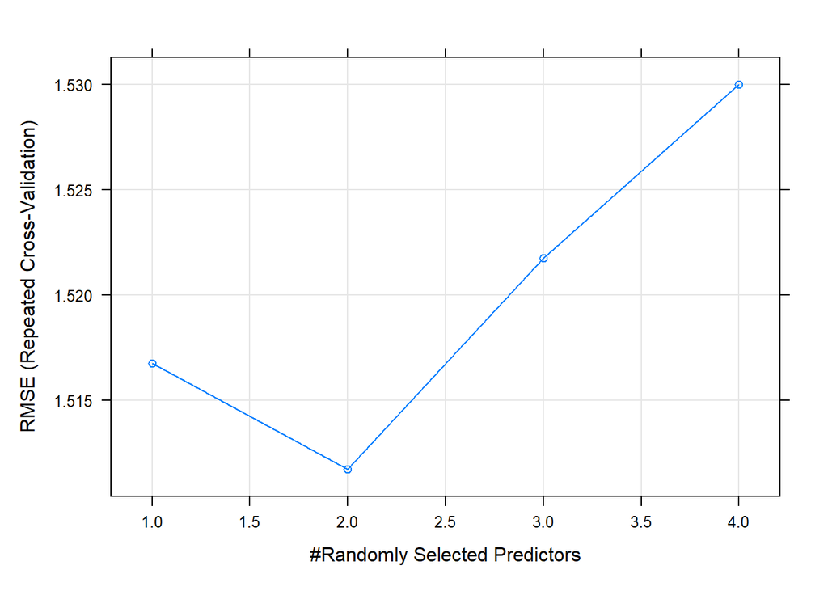

```r
plot(rf_gridsearch)
```

#Adding surgery and season also do not have an impact on the random forest model.

```r
#The best mtry value, or number of variables to try at each split is 2.
tunegrid1 <- expand.grid(.mtry=c(2))

rf_gridsearch <- train(lifestyle ~ Diagnosis + trauma, data=train, method="rf", tuneGrid=tunegrid1, trControl=control)
rf
```

[output not shown]

```r
control <- trainControl(method="repeatedcv", number=10, repeats=3, search="grid")
tunegrid <- expand.grid(.mtry=c(1))
modellist <- list()
for (ntree in c(1000, 1500, 2000, 2500)) {
 set.seed(7)
 fit <- train(lifestyle ~ Diagnosis + trauma , data=train, method="rf", tuneGrid=tunegrid, trControl=control, ntree=ntree)
 key <- toString(ntree)
 modellist[[key]] <- fit
}
# compare results
results <- resamples(modellist)
summary(results)
```

```
##
## Call:
## summary.resamples(object = results)
##
## Models: 1000, 1500, 2000, 2500
## Number of resamples: 30
##
## MAE
##           Min.  1st Qu.   Median     Mean  3rd Qu.     Max. NA's
## 1000 0.9578177 1.198593 1.279849 1.281808 1.386814 1.622264    0
## 1500 0.9561001 1.199662 1.281226 1.281429 1.387481 1.617776    0
## 2000 0.9569566 1.199618 1.283878 1.281876 1.385484 1.618585    0
## 2500 0.9570264 1.201019 1.284574 1.281819 1.385232 1.619321    0
##
## RMSE
##          Min.  1st Qu.   Median     Mean  3rd Qu.     Max. NA's
## 1000 1.015536 1.390305 1.529799 1.495552 1.627963 1.936217    0
## 1500 1.013935 1.387594 1.529266 1.495459 1.627395 1.935798    0
## 2000 1.013932 1.387807 1.529404 1.495607 1.626521 1.934924    0
## 2500 1.013831 1.389729 1.529149 1.495456 1.625803 1.935245    0
##
## Rsquared
##             Min.    1st Qu.    Median      Mean   3rd Qu.      Max. NA's
## 1000 0.001050230 0.02759170 0.1587090 0.1910324 0.3020058 0.6648212    0
## 1500 0.001087132 0.02761043 0.1550575 0.1913153 0.3017886 0.6648102    0
## 2000 0.001093504 0.02746843 0.1581429 0.1911636 0.3009730 0.6648123    0
## 2500 0.001061682 0.02677284 0.1592527 0.1912417 0.3011854 0.6648068    0
```

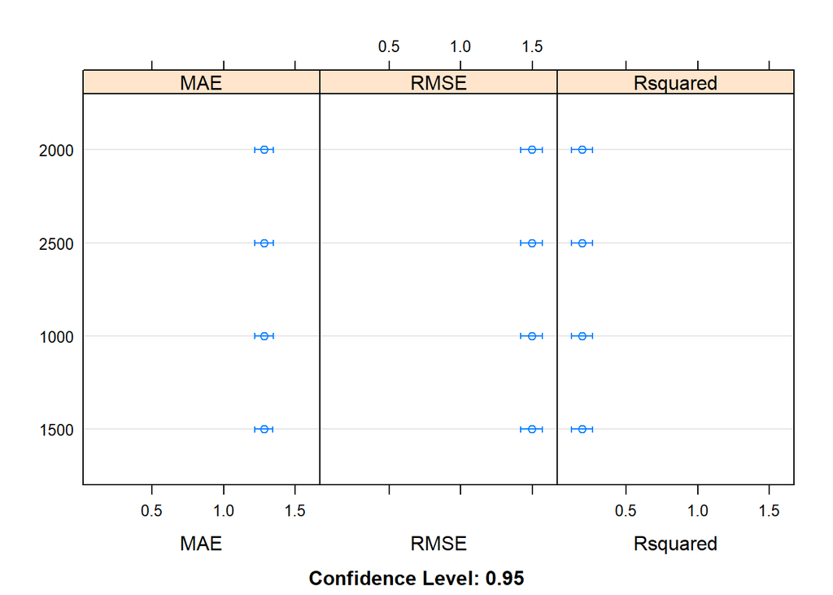

```r
dotplot(results)
```

#MAE, RMSE, and R-Squared based on different n-tree values.

```r
control <- trainControl(method="repeatedcv", number=10, repeats=3, search="grid")
tunegrid <- expand.grid(.mtry=c(2))
finalrf <- train(lifestyle ~ Diagnosis + trauma + surgery + Season, data=train, method="rf", tuneGrid=tunegrid, trControl=control, ntree=1500)
```

```r
pred1 <- predict(finalrf, test, type="raw")

act_pred <- data.frame(observed = test$lifestyle, predicted =
                      round(pred1))
act_pred
```

```
##   observed predicted
## 1        6         7
## 2        6         7
## 3        9         7
## 4        7         7
## 5        8         8
```

#The best tuned random forest model is only 40% accurate on the test data, so the linear model is more accurate.